# W3cubDocs

/scikit-learn

# sklearn.tree.DecisionTreeRegressor

**`class sklearn.tree.DecisionTreeRegressor(criterion=’mse’, splitter=’best’, max_depth=None, min_samples_split=2, min_samples_leaf=1, min_weight_fraction_leaf=0.0, max_features=None, random_state=None, max_leaf_nodes=None, min_impurity_decrease=0.0, min_impurity_split=None, presort=False)` [[source]](https://github.com/scikit-learn/scikit-learn/blob/bac89c2/sklearn/tree/tree.py#L882)**

A decision tree regressor.

Read more in the User Guide.

Parameters:

**`criterion : string, optional (default=”mse”)`**

The function to measure the quality of a split. Supported criteria are “mse” for the mean squared error, which is equal to variance reduction as feature selection criterion and minimizes the L2 loss using the mean of each terminal node, “friedman_mse”, which uses mean squared error with Friedman’s improvement score for potential splits, and “mae” for the mean absolute error, which minimizes the L1 loss using the median of each terminal node.

New in version 0.18: Mean Absolute Error (MAE) criterion.

**`splitter : string, optional (default=”best”)`**

The strategy used to choose the split at each node. Supported strategies are “best” to choose the best split and “random” to choose the best random split.

**`max_depth : int or None, optional (default=None)`**

The maximum depth of the tree. If None, then nodes are expanded until all leaves are pure or until all leaves contain less than min_samples_split samples.

**`min_samples_split : int, float, optional (default=2)`**

The minimum number of samples required to split an internal node:

- If int, then consider `min_samples_split` as the minimum number.
- If float, then `min_samples_split` is a fraction and `ceil(min_samples_split * n_samples)` are the minimum number of samples for each split.

Changed in version 0.18: Added float values for fractions.

**`min_samples_leaf : int, float, optional (default=1)`**

The minimum number of samples required to be at a leaf node. A split point at any depth will only be considered if it leaves at least `min_samples_leaf` training samples in each of the left and right branches. This may have the effect of smoothing the model, especially in regression.

- If int, then consider `min_samples_leaf` as the minimum number.
- If float, then `min_samples_leaf` is a fraction and `ceil(min_samples_leaf * n_samples)` are the minimum number of samples for each node.

Changed in version 0.18: Added float values for fractions.

**`min_weight_fraction_leaf : float, optional (default=0.)`**

The minimum weighted fraction of the sum total of weights (of all the input samples) required to be at a leaf node. Samples have equal weight when sample_weight is not provided.

**`max_features : int, float, string or None, optional (default=None)`**

The number of features to consider when looking for the best split:

- If int, then consider `max_features` features at each split.
- If float, then `max_features` is a fraction and `int(max_features * n_features)` features are considered at each split.
- If “auto”, then `max_features=n_features`.
- If “sqrt”, then `max_features=sqrt(n_features)`.
- If “log2”, then `max_features=log2(n_features)`.
- If None, then `max_features=n_features`.

Note: the search for a split does not stop until at least one valid partition of the node samples is found, even if it requires to effectively inspect more than `max_features` features.

**`random_state : int, RandomState instance or None, optional (default=None)`**

If int, random_state is the seed used by the random number generator; If RandomState instance, random_state is the random number generator; If None, the random number generator is the RandomState instance used by `np.random`.

**`max_leaf_nodes : int or None, optional (default=None)`**

Grow a tree with `max_leaf_nodes` in best-first fashion. Best nodes are defined as relative reduction in impurity. If None then unlimited number of leaf nodes.

**`min_impurity_decrease : float, optional (default=0.)`**

A node will be split if this split induces a decrease of the impurity greater than or equal to this value.

The weighted impurity decrease equation is the following:

```
N_t / N * (impurity - N_t_R / N_t * right_impurity
                    - N_t_L / N_t * left_impurity)
```

where `N` is the total number of samples, `N_t` is the number of samples at the current node, `N_t_L` is the number of samples in the left child, and `N_t_R` is the number of samples in the right child.

`N`, `N_t`, `N_t_R` and `N_t_L` all refer to the weighted sum, if `sample_weight` is passed.

New in version 0.19.

**`min_impurity_split : float,`**

Threshold for early stopping in tree growth. A node will split if its impurity is above the threshold, otherwise it is a leaf.

Deprecated since version 0.19: `min_impurity_split` has been deprecated in favor of `min_impurity_decrease` in 0.19 and will be removed in 0.21. Use `min_impurity_decrease` instead.

**`presort : bool, optional (default=False)`**

Whether to presort the data to speed up the finding of best splits in fitting. For the default settings of a decision tree on large datasets, setting this to true may slow down the training process. When using either a smaller dataset or a restricted depth, this may speed up the training.

Attributes:

**`feature_importances_ : array of shape = [n_features]`**

Return the feature importances.

**`max_features_ : int,`**

The inferred value of max_features.

**`n_features_ : int`**

The number of features when `fit` is performed.

**`n_outputs_ : int`**

The number of outputs when `fit` is performed.

**`tree_ : Tree object`**

The underlying Tree object. Please refer to `help(sklearn.tree._tree.Tree)` for attributes of Tree object and Understanding the decision tree structure for basic usage of these attributes.

See also

`DecisionTreeClassifier`

#### Notes

The default values for the parameters controlling the size of the trees (e.g. `max_depth`, `min_samples_leaf`, etc.) lead to fully grown and unpruned trees which can potentially be very large on some data sets. To reduce memory consumption, the complexity and size of the trees should be controlled by setting those parameter values.

The features are always randomly permuted at each split. Therefore, the best found split may vary, even with the same training data and `max_features=n_features`, if the improvement of the criterion is identical for several splits enumerated during the search of the best split. To obtain a deterministic behaviour during fitting, `random_state` has to be fixed.

#### References

| [1] | https://en.wikipedia.org/wiki/Decision_tree_learning |
| --- | --- |

| [2] | L. Breiman, J. Friedman, R. Olshen, and C. Stone, “Classification and Regression Trees”, Wadsworth, Belmont, CA, 1984. |
| --- | --- |

| [3] | T. Hastie, R. Tibshirani and J. Friedman. “Elements of Statistical Learning”, Springer, 2009. |
| --- | --- |

| [4] | L. Breiman, and A. Cutler, “Random Forests”, http://www.stat.berkeley.edu/~breiman/RandomForests/cc_home.htm |
| --- | --- |

#### Examples

```
>>> from sklearn.datasets import load_boston
>>> from sklearn.model_selection import cross_val_score
>>> from sklearn.tree import DecisionTreeRegressor
>>> boston = load_boston()
>>> regressor = DecisionTreeRegressor(random_state=0)
>>> cross_val_score(regressor, boston.data, boston.target, cv=10)
...
...
array([ 0.61..., 0.57..., -0.34..., 0.41..., 0.75...,
        0.07..., 0.29..., 0.33..., -1.42..., -1.77...])
```

#### Methods

| `apply`(X[, check_input]) | Returns the index of the leaf that each sample is predicted as. |
| --- | --- |
| `decision_path`(X[, check_input]) | Return the decision path in the tree |
| `fit`(X, y[, sample_weight, check_input, …]) | Build a decision tree regressor from the training set (X, y). |
| `get_params`([deep]) | Get parameters for this estimator. |
| `predict`(X[, check_input]) | Predict class or regression value for X. |
| `score`(X, y[, sample_weight]) | Returns the coefficient of determination R^2 of the prediction. |
| `set_params`(**params) | Set the parameters of this estimator. |

**`__init__(criterion=’mse’, splitter=’best’, max_depth=None, min_samples_split=2, min_samples_leaf=1, min_weight_fraction_leaf=0.0, max_features=None, random_state=None, max_leaf_nodes=None, min_impurity_decrease=0.0, min_impurity_split=None, presort=False)` [[source]](https://github.com/scikit-learn/scikit-learn/blob/bac89c2/sklearn/tree/tree.py#L1073)**

**`apply(X, check_input=True)` [[source]](https://github.com/scikit-learn/scikit-learn/blob/bac89c2/sklearn/tree/tree.py#L442)**

Returns the index of the leaf that each sample is predicted as.

New in version 0.17.

[output not shown]

**`decision_path(X, check_input=True)` [[source]](https://github.com/scikit-learn/scikit-learn/blob/bac89c2/sklearn/tree/tree.py#L471)**

Return the decision path in the tree

New in version 0.18.

[output not shown]

**`feature_importances_`**

Return the feature importances.

The importance of a feature is computed as the (normalized) total reduction of the criterion brought by that feature. It is also known as the Gini importance.

| Returns: | **`feature_importances_ : array, shape = [n_features]`** |
| --- | --- |

**`fit(X, y, sample_weight=None, check_input=True, X_idx_sorted=None)` [[source]](https://github.com/scikit-learn/scikit-learn/blob/bac89c2/sklearn/tree/tree.py#L1100)**

Build a decision tree regressor from the training set (X, y).

[output not shown]

**`get_params(deep=True)` [[source]](https://github.com/scikit-learn/scikit-learn/blob/bac89c2/sklearn/base.py#L166)**

Get parameters for this estimator.

| Parameters: | **`deep : boolean, optional`** If True, will return the parameters for this estimator and contained subobjects that are estimators. |
| --- | --- |
| Returns: | **`params : mapping of string to any`** Parameter names mapped to their values. |

**`predict(X, check_input=True)` [[source]](https://github.com/scikit-learn/scikit-learn/blob/bac89c2/sklearn/tree/tree.py#L391)**

Predict class or regression value for X.

For a classification model, the predicted class for each sample in X is returned. For a regression model, the predicted value based on X is returned.

[output not shown]

**`score(X, y, sample_weight=None)` [[source]](https://github.com/scikit-learn/scikit-learn/blob/bac89c2/sklearn/base.py#L296)**

Returns the coefficient of determination R^2 of the prediction.

The coefficient R^2 is defined as (1 - u/v), where u is the residual sum of squares ((y_true - y_pred) ** 2).sum() and v is the total sum of squares ((y_true - y_true.mean()) ** 2).sum(). The best possible score is 1.0 and it can be negative (because the model can be arbitrarily worse). A constant model that always predicts the expected value of y, disregarding the input features, would get a R^2 score of 0.0.

[output not shown]

**`set_params(**params)` [[source]](https://github.com/scikit-learn/scikit-learn/blob/bac89c2/sklearn/base.py#L189)**

Set the parameters of this estimator.

The method works on simple estimators as well as on nested objects (such as pipelines). The latter have parameters of the form `<component>__<parameter>` so that it’s possible to update each component of a nested object.

| Returns: | **self** |
| --- | --- |

## Examples using `sklearn.tree.DecisionTreeRegressor`

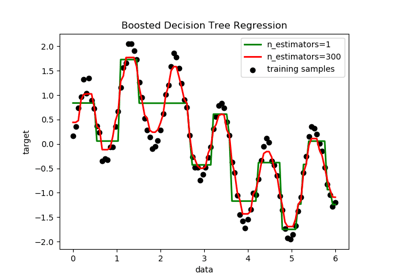

Decision Tree Regression with AdaBoost

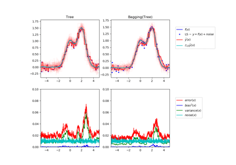

Single estimator versus bagging: bias-variance decomposition

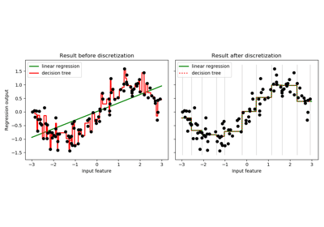

Using KBinsDiscretizer to discretize continuous features

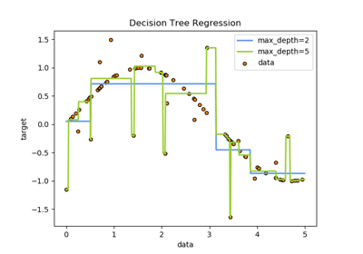

Decision Tree Regression

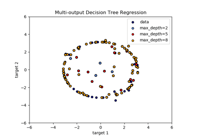

Multi-output Decision Tree Regression

© 2007–2018 The scikit-learn developers  
Licensed under the 3-clause BSD License.  
http://scikit-learn.org/stable/modules/generated/sklearn.tree.DecisionTreeRegressor.html